# Capstone Project

AD

February 20, 2019

## Introduction

This is a Capstone Project to build an application to predict next word using NLP.

The goal of this exercise is to create a product to highlight the prediction algorithm and to provide an interface that can be accessed by others. 1. A Shiny app that takes as input a phrase (multiple words) in a text box input and outputs a prediction of the next word.

2. A slide deck presentation.
3. The following steps have been considered prior to building the app.
- Exploratory Data Analysis.
- Getting and Cleaning Data
- Tokenization

## Load Libraries

```r
library(tm)
library(ggplot2)
library(RWeka)
library(R.utils)
library(dplyr)
library(wordcloud)
library(corpus)
library(ngram)
library(NLP)
library(openNLP)
library(SnowballC)
```

## Download the data from the Coursera site Capstone Dataset

```r
setwd("C:/Capstone Final")

traindata <- download.file("https://d396qusza40orc.cloudfront.net/dsscapstone/dataset/Coursera-SwiftKey.zip","datafile.zip")
unzip("datafile.zip")
```

## Use en_US Folder to Read the Lines in English

- en_US.twitter.txt
- en_US.blogs.txt
- en_US.news.txt

```r
rtwit <- file("C:/Capstone Final/final/en_US/en_US.twitter.txt", "rb",encoding = "UTF-8")
readrtwit <- readLines(rtwit,skipNul = TRUE, warn = FALSE)


rblog <- file("C:/Capstone Final/final/en_US/en_US.blogs.txt","rb",encoding = "UTF-8")
readrblog <- readLines(rblog,skipNul = TRUE, warn = FALSE)


rnews <- file("C:/Capstone Final/final/en_US/en_US.news.txt","rb",encoding = "UTF-8")
readrnews <- readLines(rnews,skipNul = TRUE, warn = FALSE)
```

## Exploratory Data Analysis

Basic summaries of the three files en_US.twitter.txt,en_US.blogs.txt,en_US.news.txt * Size * Number of Lines * Word count

```r
twit_size <- format(object.size(readrtwit), "MB")
twit_lines <- length(readrtwit)
twit_word <- wordcount(readrtwit, sep = " ", count.function = sum)

blog_size <- format(object.size(readrblog), "MB")
blog_lines <- length(readrblog)
blog_word <- wordcount(readrblog, sep = " ", count.function = sum)

news_size <- format(object.size(readrnews), "MB")
news_lines <- length(readrnews)
news_word <- wordcount(readrblog, sep = " ", count.function = sum)

file_size <- c(twit_size,blog_size,news_size)
file_linescount <- c(twit_lines,blog_lines,news_lines)
file_wordcount <- c(twit_word,blog_word,news_word)

df <- data.frame("Files " = c("Twitter","Blog","News"),file_size,file_linescount,file_wordcount)

df
```

```
##    Files. file_size file_linescount file_wordcount
## 1 Twitter  301.4 Mb         2360148       30373583
## 2    Blog  248.5 Mb          899288       37334131
## 3    News  249.6 Mb         1010242       37334131
```

## Getting and Cleaning the Data

The data is huge, hence I am considering a very small subset. This subset is further cleaned.

```r
set.seed(65513)

samp_rtwit <- sample(readrtwit,length(readrtwit)*0.001,replace = TRUE)
samp_rblog <- sample(readrblog,length(readrblog)*0.001,replace = TRUE)
samp_rnews <- sample(readrnews,length(readrnews)*0.001,replace = TRUE)

sampleTotal <- c(samp_rtwit, samp_rblog, samp_rnews)
length(sampleTotal)
```

```
## [1] 4269
```

```r
writeLines(sampleTotal, "C:/Capstone Final/samplefile.txt")

textCon <- file("C:/Capstone Final/samplefile.txt")
```

## Convert the data into Corpus

```r
corpdata <- readLines(textCon)
corpdata <- VCorpus(VectorSource(corpdata))
```

## Clean Data

```r
corpdata <- tm_map(corpdata, content_transformer(function(x) iconv(x, to="UTF-8", sub="byte")))
corpdata <- tm_map(corpdata, content_transformer(tolower), lazy = TRUE)
corpdata <- tm_map(corpdata, content_transformer(removePunctuation), preserve_intra_word_dashes=TRUE)

removeURL <- function(x) gsub("http[[:alnum:]]*", "", x)
corpdata <- tm_map(corpdata, content_transformer(removeURL))
corpdata <- tm_map(corpdata, removeWords, stopwords("english"))
corpdata <- tm_map(corpdata, stripWhitespace)
corpdata <- tm_map(corpdata, PlainTextDocument)
saveRDS(corpdata, file = "C:/Capstone Final/finalCorpus.RData")

final_corpdata <- readRDS("C:/Capstone Final/finalCorpus.RData")
final_corpdata_df <-data.frame(text=unlist(sapply(final_corpdata,`[`,"content")),stringsAsFactors= FALSE)
```

## Tokenize Using TermDocumentMatrix

Use TermDocumentMatrix to tokenize the corpus data using Ngram Tokenizer Tokenization breaks the sentences into a set of words or tokens based on the ngram selections.

- One Gram Shows a single word and its frequency of use

```r
onegram <- function(x) NGramTokenizer(x,Weka_control(min = 1, max = 1,delimiters=" \\r\\n\\t.,;:\"()?!"))
onegrammat <- TermDocumentMatrix(corpdata,control = list(tokenize=onegram))
onegrammat
```

```
## <<TermDocumentMatrix (terms: 15526, documents: 4269)>>
## Non-/sparse entries: 51940/66228554
## Sparsity           : 100%
## Maximal term length: 62
## Weighting          : term frequency (tf)
```

```r
onegrammat1 <- as.matrix(onegrammat)
onegramsort <- sort(rowSums(onegrammat1), decreasing = TRUE)
onegramsortdf <- data.frame(word = names(onegramsort),freq=onegramsort)
head(onegramsortdf)
```

```
##      word freq
## one   one  299
## will will  283
## just just  282
## said said  274
## like like  244
## can   can  243
```

[figure not shown]

```r
ggplot(data=onegramsortdf[1:40,], aes(x=reorder(word,-freq),y=freq)) + geom_bar(stat = "identity",color = "gray", fill = "red") + coord_flip() + labs(title = "One Gram Plot") + xlab("Frequency Count") + ylab("Word")
```

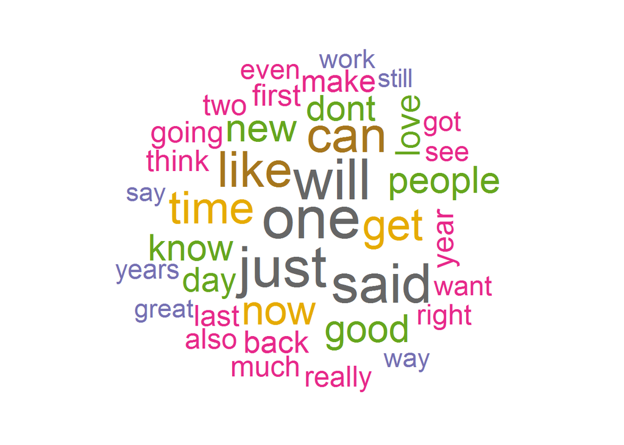

```r
wordcloud(onegramsortdf$word,onegramsortdf$freq,min.freq = 100,max.words = 100,random.order = FALSE, colors = brewer.pal(8,"Dark2"))
```

```r
onegramsortdf$word <- as.character(onegramsortdf$word)
write.csv(onegramsortdf[onegramsortdf$freq > 1,],"C:/Capstone Final/Milestone report/onegram.csv",row.names = F)
onegramsortdf <- read.csv("C:/Capstone Final/Milestone report/onegram.csv",stringsAsFactors = F)
saveRDS(onegramsortdf,file = "C:/Capstone Final/ShinyApp/onegram.RData")
```

- Bi Gram Shows two words and its frequency of use

```r
bigram <- function(x) NGramTokenizer(x,Weka_control(min = 2, max = 2,delimiters = " \\r\\n\\t.,;:\"()?!"))
bigrammat <- TermDocumentMatrix(corpdata,control = list(tokenize=bigram))
bigrammat
```

```
## <<TermDocumentMatrix (terms: 50099, documents: 4269)>>
## Non-/sparse entries: 52733/213819898
## Sparsity           : 100%
## Maximal term length: 72
## Weighting          : term frequency (tf)
```

```r
bigrammat1 <- as.matrix(bigrammat)
bigramsort <- sort(rowSums(bigrammat1), decreasing = TRUE)
bigramsortdf <- data.frame(word = names(bigramsort),freq=bigramsort)
head(bigramsortdf)
```

```
##                word freq
## right now right now   36
## new york   new york   24
## last year last year   23
## dont know dont know   20
## years ago years ago   20
## make sure make sure   17
```

```r
bigramsortdf$word <- as.character(bigramsortdf$word)
bisplit <- strsplit(bigramsortdf$word,split = " ")

bigramsortdf <- transform(bigramsortdf, one = sapply(bisplit,"[[",1), two = sapply(bisplit,"[[",2))
bigramsortdf <- data.frame(word1=bigramsortdf$one,word2=bigramsortdf$two,freq=bigramsortdf$freq,stringsAsFactors = FALSE)


write.csv(bigramsortdf[bigramsortdf$freq > 1,],"C:/Capstone Final/Milestone report/bigram.csv",row.names = F)
onegramsortdf <- read.csv("C:/Capstone Final/Milestone report/bigram.csv",stringsAsFactors = F)
saveRDS(bigramsortdf,file = "C:/Capstone Final/ShinyApp/bigram.RData")
```

- Tri Gram Shows three words and its frequency of use

```r
trigram <- function(x) NGramTokenizer(x,Weka_control(min = 3, max = 3,delimiters = " \\r\\n\\t.,;:\"()?!"))
trigrammat <- TermDocumentMatrix(corpdata,control = list(tokenize=trigram))
trigrammat
```

```
## <<TermDocumentMatrix (terms: 48740, documents: 4269)>>
## Non-/sparse entries: 48867/208022193
## Sparsity           : 100%
## Maximal term length: 82
## Weighting          : term frequency (tf)
```

```r
trigrammat_sparse <- removeSparseTerms(trigrammat,0.99)
trigrammat1 <- as.matrix(trigrammat)
trigramsort <- sort(rowSums(trigrammat1), decreasing = TRUE)
trigramsortdf <- data.frame(word = names(trigramsort),freq=trigramsort)
head(trigramsortdf)
```

```
##                                          word freq
## happy mothers day           happy mothers day    8
## lead background vocals lead background vocals    5
## dont even know                 dont even know    4
## love love love                 love love love    4
## cant wait see                   cant wait see    3
## cents per share               cents per share    3
```

```r
trigramsortdf$word <- as.character(trigramsortdf$word)

trisplit <- strsplit(trigramsortdf$word,split = " ")
trigramsortdf <- transform(trigramsortdf,one = sapply(trisplit,"[[",1),two = sapply(trisplit,"[[",2),three = sapply(trisplit,"[[",3) )

trigramsortdf <- data.frame(word1=trigramsortdf$one,word2=trigramsortdf$two,word3=trigramsortdf$three,freq=trigramsortdf$freq,stringsAsFactors = FALSE)

write.csv(trigramsortdf[trigramsortdf$freq > 1,],"C:/Capstone Final/Milestone report/trigram.csv",row.names = F)
trigramsortdf <- read.csv("C:/Capstone Final/Milestone report/trigram.csv",stringsAsFactors = F)
saveRDS(trigramsortdf,file = "C:/Capstone Final/ShinyApp/trigram.RData")
```

- Quad Gram Shows four words and its frequency of use

```r
quadgram <- function(x) NGramTokenizer(x,Weka_control(min = 4, max = 4,delimiters = " \\r\\n\\t.,;:\"()?!"))
quadgrammat <- TermDocumentMatrix(corpdata,control = list(tokenize=quadgram))
quadgrammat
```

```
## <<TermDocumentMatrix (terms: 44931, documents: 4269)>>
## Non-/sparse entries: 44982/191765457
## Sparsity           : 100%
## Maximal term length: 94
## Weighting          : term frequency (tf)
```

```r
quadgrammat_sparse <- removeSparseTerms(quadgrammat,0.99)
quadgrammat1 <- as.matrix(quadgrammat)
quadgramsort <- sort(rowSums(quadgrammat1), decreasing = TRUE)
quadgramsortdf <- data.frame(word = names(quadgramsort),freq=quadgramsort)
head(quadgramsortdf)
```

```
##                                                                  word freq
## 3133552 bottles thatâs assuming   3133552 bottles thatâs assuming    2
## 500 mgm2 max 1000                                   500 mgm2 max 1000    2
## 63 cents per share                                 63 cents per share    2
## 9400655 bottles chemical laden         9400655 bottles chemical laden    2
## alternative thatâs still 3133552 alternative thatâs still 3133552    2
## armed robbery five counts                   armed robbery five counts    2
```

```r
quadgramsortdf$word <- as.character(quadgramsortdf$word)

quadsplit <- strsplit(quadgramsortdf$word,split = " ")
quadgramsortdf <- transform(quadgramsortdf,one=sapply(quadsplit,"[[",1),two=sapply(quadsplit,"[[",2),three= sapply(quadsplit,"[[",3),four=sapply(quadsplit,"[[",4) )

quadgramsortdf <- data.frame(word1=quadgramsortdf$one,word2=quadgramsortdf$two,word3=quadgramsortdf$three,word4=quadgramsortdf$four,freq=quadgramsortdf$freq,stringsAsFactors = FALSE)

write.csv(quadgramsortdf[quadgramsortdf$freq > 1,],"C:/Capstone Final/Milestone report/quadgram.csv",row.names = F)
quadgramsortdf <- read.csv("C:/Capstone Final/Milestone report/quadgram.csv",stringsAsFactors = F)
saveRDS(quadgramsortdf,file = "C:/Capstone Final/ShinyApp/quadgram.RData")
```

## Observations and Future Plans

- Plan is to consider a bigger subset data.
- Create a prediction algorithm and Shiny app.
- Plan is to use the next plotted n-gram to predict the next word in a user text.
- Plan is to create a Shiny App that will take this text user input and predict based on these n-gram algorithms.